# Healthcare Data Analysis

#### Dataset info:

- Sample Dataset Contains the Healthcare Data of 2017 of Some foreign Countries . In this project I have done the Exploratory Data Analysis(EDA) on Healthcare Data by using python(Pandas, Seaborn and Matplotlib).

```python
# import the required libraries

import numpy as np
import pandas as pd
import matplotlib.pyplot as plt
import seaborn as sns
%matplotlib inline
```

#### Load the data file and look at some records of the data

```python
df= pd.read_excel('Medicare Inpatient 2017.xlsx')
df
```

|  | DRG Definition | Provider Id | Total Discharges | Average Covered Charges | Average Total Payments | Average Medicare Payments |
| --- | --- | --- | --- | --- | --- | --- |
| 0 | 023 - CRANIOTOMY W MAJOR DEVICE IMPLANT OR ACU... | 10001 | 28 | 117117.78570 | 25823.714290 | 24057.392860 |
| 1 | 025 - CRANIOTOMY & ENDOVASCULAR INTRACRANIAL P... | 10001 | 32 | 98357.56250 | 20688.343750 | 19791.406250 |
| 2 | 027 - CRANIOTOMY & ENDOVASCULAR INTRACRANIAL P... | 10001 | 11 | 69153.54546 | 11811.181820 | 8194.363636 |
| 3 | 037 - EXTRACRANIAL PROCEDURES W MCC | 10001 | 12 | 100427.33330 | 19134.000000 | 18154.000000 |
| 4 | 038 - EXTRACRANIAL PROCEDURES W CC | 10001 | 17 | 58199.47059 | 8519.470588 | 6714.882353 |
| ... | ... | ... | ... | ... | ... | ... |
| 196320 | 683 - RENAL FAILURE W CC | 670120 | 14 | 50528.14286 | 4924.071429 | 3647.500000 |
| 196321 | 690 - KIDNEY & URINARY TRACT INFECTIONS W/O MCC | 670120 | 23 | 47396.65217 | 4251.260870 | 3450.217391 |
| 196322 | 871 - SEPTICEMIA OR SEVERE SEPSIS W/O MV >96 H... | 670120 | 22 | 147342.18180 | 18504.954550 | 13261.090910 |
| 196323 | 470 - MAJOR JOINT REPLACEMENT OR REATTACHMENT ... | 670122 | 25 | 118123.00000 | 11911.400000 | 11016.520000 |
| 196324 | 871 - SEPTICEMIA OR SEVERE SEPSIS W/O MV >96 H... | 670122 | 17 | 82812.29412 | 10706.882350 | 10165.000000 |

196325 rows × 6 columns

#### Check the various attributes of data like shape(rows and columns),columns,datatypes

```python
df.shape
```

```
(196325, 6)
```

```python
df.columns.values
```

```
array(['DRG Definition', 'Provider Id', 'Total Discharges',
       'Average Covered Charges', 'Average Total Payments',
       'Average Medicare Payments'], dtype=object)
```

```python
# Checking the data types of all the columns

df.dtypes
```

```
DRG Definition                object
Provider Id                    int64
Total Discharges               int64
Average Covered Charges      float64
Average Total Payments       float64
Average Medicare Payments    float64
dtype: object
```

- we can see above all the data sets having the correct data types format so no need to change we can move into our further analysis.

# Data Cleaning

- For features with very high number of missing values- it is better to drop those columns as they give very less insight on analysis.
- As there is not any specific rule on what criteria do we delete the columns with high number of missing values, but generally you can delete the columns, if you have more than 30-40% of missing values. but again there is a catch here, for example, Is_Car & Car_Type, people having no cars, will obviously have Car_Type as NaN(null), but that does not make this column useless, so decisions has to be taken Wisely.

```python
df.isnull().sum()
```

```
DRG Definition               0
Provider Id                  0
Total Discharges             0
Average Covered Charges      0
Average Total Payments       0
Average Medicare Payments    0
dtype: int64
```

### As we don't have any Missing or Null values present inside the entire dataset so, no Data Cleaning is required.

```python
# Checking about duplicated values

df.duplicated().sum()
```

```
0
```

### The dataset also don't have any duplicated values present so we can move into our further analysis.

## Changing the name of the Columns

```python
df.rename({'DRG Definition':'DRG_Definition','Provider Id':'Provider_Id','Total Discharges':'Total_Discharges','Average Covered Charges':'Average_Covered_Charges','Average Total Payments':'Average_Total_Payments','Average Medicare Payments':'Average_Medicare_Payments' },axis=1,inplace=True)
```

#### Checking the Descriptive Statistics of numeric variables

```python
df.describe()
```

|  | Provider_Id | Total_Discharges | Average_Covered_Charges | Average_Total_Payments | Average_Medicare_Payments |
| --- | --- | --- | --- | --- | --- |
| count | 196325.000000 | 196325.000000 | 1.963250e+05 | 196325.000000 | 196325.000000 |
| mean | 256061.085690 | 37.604421 | 6.116615e+04 | 13978.194700 | 11816.235001 |
| std | 151405.498703 | 57.259325 | 7.301412e+04 | 14800.590340 | 13230.938068 |
| min | 10001.000000 | 11.000000 | 2.644778e+03 | 2497.888889 | 0.000000 |
| 25% | 110076.000000 | 14.000000 | 2.412314e+04 | 6509.441558 | 5133.818182 |
| 50% | 240115.000000 | 21.000000 | 4.012152e+04 | 9658.380952 | 8041.960784 |
| 75% | 380040.000000 | 39.000000 | 7.090856e+04 | 15496.272730 | 13089.968750 |
| max | 670122.000000 | 4255.000000 | 3.325523e+06 | 515706.741900 | 491509.677400 |

```python
# Look at the top 5 records of data

df.head()
```

|  | DRG_Definition | Provider_Id | Total_Discharges | Average_Covered_Charges | Average_Total_Payments | Average_Medicare_Payments |
| --- | --- | --- | --- | --- | --- | --- |
| 0 | 023 - CRANIOTOMY W MAJOR DEVICE IMPLANT OR ACU... | 10001 | 28 | 117117.78570 | 25823.714290 | 24057.392860 |
| 1 | 025 - CRANIOTOMY & ENDOVASCULAR INTRACRANIAL P... | 10001 | 32 | 98357.56250 | 20688.343750 | 19791.406250 |
| 2 | 027 - CRANIOTOMY & ENDOVASCULAR INTRACRANIAL P... | 10001 | 11 | 69153.54546 | 11811.181820 | 8194.363636 |
| 3 | 037 - EXTRACRANIAL PROCEDURES W MCC | 10001 | 12 | 100427.33330 | 19134.000000 | 18154.000000 |
| 4 | 038 - EXTRACRANIAL PROCEDURES W CC | 10001 | 17 | 58199.47059 | 8519.470588 | 6714.882353 |

```python
# Concise Summary of the dataframe

df.info()
```

```
<class 'pandas.core.frame.DataFrame'>
RangeIndex: 196325 entries, 0 to 196324
Data columns (total 6 columns):
 #   Column                     Non-Null Count   Dtype
---  ------                     --------------   -----
 0   DRG_Definition             196325 non-null  object
 1   Provider_Id                196325 non-null  int64
 2   Total_Discharges           196325 non-null  int64
 3   Average_Covered_Charges    196325 non-null  float64
 4   Average_Total_Payments     196325 non-null  float64
 5   Average_Medicare_Payments  196325 non-null  float64
dtypes: float64(3), int64(2), object(1)
memory usage: 9.0+ MB
```

# Data Exploration

### Bivariate Analysis

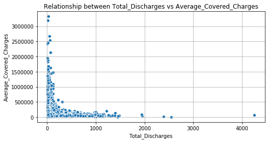

```python
plt.figure(figsize=(8,4))
sns.scatterplot(x='Total_Discharges',y='Average_Covered_Charges',data=df)
plt.title('Relationship between Total_Discharges vs Average_Covered_Charges')
plt.grid()
plt.show()
```

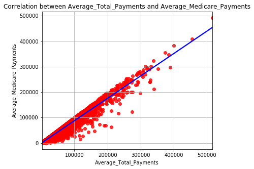

```python
plt.figure(figsize=(6,5))
sns.regplot(x='Average_Total_Payments',y='Average_Medicare_Payments',data=df,scatter_kws={'color':'red'},line_kws={'color':'blue'})
plt.title('Correlation between Average_Total_Payments and Average_Medicare_Payments')
plt.grid()
plt.show()
```

## Multivariate analysis

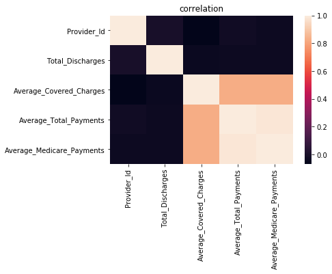

```python
sns.heatmap(df.corr())
plt.title('correlation')
plt.show()
```

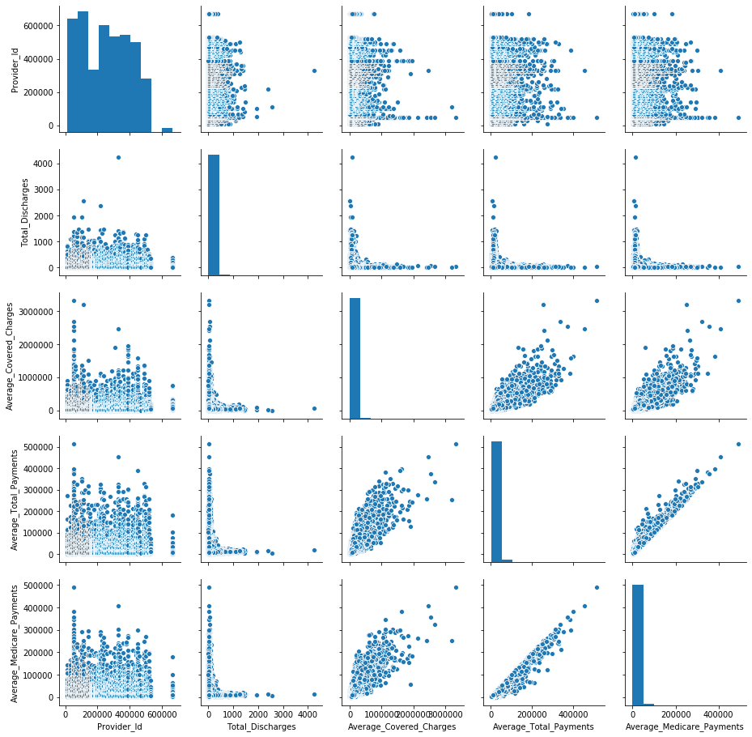

```python
sns.pairplot(df)

plt.show()
```

```python
# Checking up the unique values

df.DRG_Definition.unique()
```

```
array(['023 - CRANIOTOMY W MAJOR DEVICE IMPLANT OR ACUTE CNS PDX W MCC OR CHEMOTHE',
       '025 - CRANIOTOMY & ENDOVASCULAR INTRACRANIAL PROCEDURES W MCC',
       '027 - CRANIOTOMY & ENDOVASCULAR INTRACRANIAL PROCEDURES W/O CC/MCC',
       '037 - EXTRACRANIAL PROCEDURES W MCC',
       '038 - EXTRACRANIAL PROCEDURES W CC',
       '039 - EXTRACRANIAL PROCEDURES W/O CC/MCC',
       '054 - NERVOUS SYSTEM NEOPLASMS W MCC',
       '056 - DEGENERATIVE NERVOUS SYSTEM DISORDERS W MCC',
       '057 - DEGENERATIVE NERVOUS SYSTEM DISORDERS W/O MCC',
       '062 - ISCHEMIC STROKE, PRECEREBRAL OCCLUSION OR TRANSIENT ISCHEMIA W THROM',
       '064 - INTRACRANIAL HEMORRHAGE OR CEREBRAL INFARCTION W MCC',
       '065 - INTRACRANIAL HEMORRHAGE OR CEREBRAL INFARCTION W CC OR TPA IN 24 HRS',
       '066 - INTRACRANIAL HEMORRHAGE OR CEREBRAL INFARCTION W/O CC/MCC',
       '069 - TRANSIENT ISCHEMIA',
       '070 - NONSPECIFIC CEREBROVASCULAR DISORDERS W MCC',
       '071 - NONSPECIFIC CEREBROVASCULAR DISORDERS W CC',
       '073 - CRANIAL & PERIPHERAL NERVE DISORDERS W MCC',
       '074 - CRANIAL & PERIPHERAL NERVE DISORDERS W/O MCC',
       '086 - TRAUMATIC STUPOR & COMA, COMA <1 HR W CC',
       '087 - TRAUMATIC STUPOR & COMA, COMA <1 HR W/O CC/MCC',
       '091 - OTHER DISORDERS OF NERVOUS SYSTEM W MCC',
       '092 - OTHER DISORDERS OF NERVOUS SYSTEM W CC',
       '100 - SEIZURES W MCC', '101 - SEIZURES W/O MCC',
       '103 - HEADACHES W/O MCC', '149 - DYSEQUILIBRIUM',
       '163 - MAJOR CHEST PROCEDURES W MCC',
       '164 - MAJOR CHEST PROCEDURES W CC',
       '166 - OTHER RESP SYSTEM O.R. PROCEDURES W MCC',
       '176 - PULMONARY EMBOLISM W/O MCC',
       '177 - RESPIRATORY INFECTIONS & INFLAMMATIONS W MCC',
       '180 - RESPIRATORY NEOPLASMS W MCC',
       '189 - PULMONARY EDEMA & RESPIRATORY FAILURE',
       '190 - CHRONIC OBSTRUCTIVE PULMONARY DISEASE W MCC',
       '191 - CHRONIC OBSTRUCTIVE PULMONARY DISEASE W CC',
       '192 - CHRONIC OBSTRUCTIVE PULMONARY DISEASE W/O CC/MCC',
       '193 - SIMPLE PNEUMONIA & PLEURISY W MCC',
       '194 - SIMPLE PNEUMONIA & PLEURISY W CC',
       '195 - SIMPLE PNEUMONIA & PLEURISY W/O CC/MCC',
       '202 - BRONCHITIS & ASTHMA W CC/MCC',
       '203 - BRONCHITIS & ASTHMA W/O CC/MCC',
       '207 - RESPIRATORY SYSTEM DIAGNOSIS W VENTILATOR SUPPORT >96 HOURS',
```

[output cut: 487 more lines]

```
       '934 - FULL THICKNESS BURN W/O SKIN GRFT OR INHAL INJ',
       '619 - O.R. PROCEDURES FOR OBESITY W MCC',
       '622 - SKIN GRAFTS & WOUND DEBRID FOR ENDOC, NUTRIT & METAB DIS W MCC',
       '098 - NON-BACTERIAL INFECT OF NERVOUS SYS EXC VIRAL MENINGITIS W CC',
       '744 - D&C, CONIZATION, LAPAROSCOPY & TUBAL INTERRUPTION W CC/MCC',
       '102 - HEADACHES W MCC',
       '547 - CONNECTIVE TISSUE DISORDERS W/O CC/MCC',
       '255 - UPPER LIMB & TOE AMPUTATION FOR CIRC SYSTEM DISORDERS W MCC',
       '414 - CHOLECYSTECTOMY EXCEPT BY LAPAROSCOPE W/O C.D.E. W MCC',
       '077 - HYPERTENSIVE ENCEPHALOPATHY W MCC',
       '256 - UPPER LIMB & TOE AMPUTATION FOR CIRC SYSTEM DISORDERS W CC',
       '686 - KIDNEY & URINARY TRACT NEOPLASMS W MCC',
       '766 - CESAREAN SECTION W/O CC/MCC',
       '201 - PNEUMOTHORAX W/O CC/MCC',
       '198 - INTERSTITIAL LUNG DISEASE W/O CC/MCC'], dtype=object)
```

## Finding Some DRG_Definitions Average_Covered_Charges, Average_Total_Payments, Average_Medicare_Payments and Total_Discharges Below .

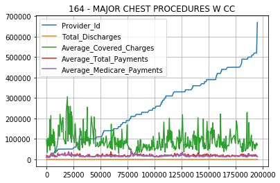

```python
dd= df[df.DRG_Definition=='164 - MAJOR CHEST PROCEDURES W CC'].plot()
dd
plt.grid()
plt.title('164 - MAJOR CHEST PROCEDURES W CC')
plt.show()
```

- You can See the above chart and get the values but for More confirmation about the exact value or to get the exact or accurate values we can use the max and min method for our analysis below.

```python
df.loc[df.DRG_Definition=='164 - MAJOR CHEST PROCEDURES W CC',['Total_Discharges','Average_Covered_Charges','Average_Total_Payments','Average_Medicare_Payments']].max()
```

```
Total_Discharges                177.00000
Average_Covered_Charges      307431.62500
Average_Total_Payments        46656.68966
Average_Medicare_Payments     45612.72414
dtype: float64
```

```python
df.loc[df.DRG_Definition=='164 - MAJOR CHEST PROCEDURES W CC',['Total_Discharges','Average_Covered_Charges','Average_Total_Payments','Average_Medicare_Payments']].min()
```

```
Total_Discharges                11.00000
Average_Covered_Charges      16940.30556
Average_Total_Payments       13060.40000
Average_Medicare_Payments    10783.83333
dtype: float64
```

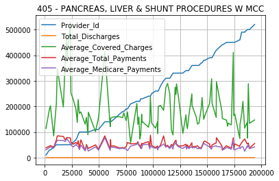

```python
dd= df[df.DRG_Definition=='405 - PANCREAS, LIVER & SHUNT PROCEDURES W MCC'].plot()
plt.legend(loc='best')
dd
plt.grid()
plt.title('405 - PANCREAS, LIVER & SHUNT PROCEDURES W MCC')
plt.show()
```

- You can See the above chart and get the values but for More confirmation about the exact value or to get the exact or accurate values we can use the max and min method for our analysis below.

```python
df.loc[df.DRG_Definition=='405 - PANCREAS, LIVER & SHUNT PROCEDURES W MCC',['Total_Discharges','Average_Covered_Charges','Average_Total_Payments','Average_Medicare_Payments']].max()
```

```
Total_Discharges                 70.00000
Average_Covered_Charges      529302.07140
Average_Total_Payments        87806.11539
Average_Medicare_Payments     77859.83333
dtype: float64
```

```python
df.loc[df.DRG_Definition=='405 - PANCREAS, LIVER & SHUNT PROCEDURES W MCC',['Total_Discharges','Average_Covered_Charges','Average_Total_Payments','Average_Medicare_Payments']].min()
```

```
Total_Discharges                11.00000
Average_Covered_Charges      57809.03846
Average_Total_Payments       27506.68750
Average_Medicare_Payments    24801.54546
dtype: float64
```

```python
m_data= df.loc[df.DRG_Definition=='693 - URINARY STONES W/O ESW LITHOTRIPSY W MCC']
m_data
```

|  | DRG_Definition | Provider_Id | Total_Discharges | Average_Covered_Charges | Average_Total_Payments | Average_Medicare_Payments |
| --- | --- | --- | --- | --- | --- | --- |
| 72560 | 693 - URINARY STONES W/O ESW LITHOTRIPSY W MCC | 180067 | 11 | 42079.54546 | 12388.63636 | 9586.727273 |
| 193757 | 693 - URINARY STONES W/O ESW LITHOTRIPSY W MCC | 520098 | 11 | 38550.00000 | 13093.36364 | 10475.636360 |

```python
dd= df.loc[df.DRG_Definition=='157 - DENTAL & ORAL DISEASES W MCC']
dd
```

|  | DRG_Definition | Provider_Id | Total_Discharges | Average_Covered_Charges | Average_Total_Payments | Average_Medicare_Payments |
| --- | --- | --- | --- | --- | --- | --- |
| 95572 | 157 - DENTAL & ORAL DISEASES W MCC | 240010 | 12 | 87134.25000 | 49866.08333 | 9091.916667 |
| 120952 | 157 - DENTAL & ORAL DISEASES W MCC | 330101 | 11 | 87706.45455 | 21625.45455 | 18911.090910 |
| 130225 | 157 - DENTAL & ORAL DISEASES W MCC | 340030 | 11 | 43114.00000 | 17894.72727 | 10725.909090 |

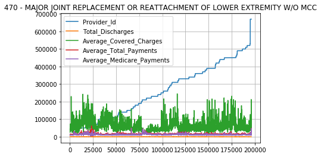

```python
dd= df[df.DRG_Definition=='470 - MAJOR JOINT REPLACEMENT OR REATTACHMENT OF LOWER EXTREMITY W/O MCC'].plot()
dd
plt.grid()
plt.title('470 - MAJOR JOINT REPLACEMENT OR REATTACHMENT OF LOWER EXTREMITY W/O MCC')
plt.show()
```

- You can See the above chart and get the values but for More confirmation about the exact value or to get the exact or accurate values we can use the max and min method for our analysis below.

```python
df.loc[df.DRG_Definition=='470 - MAJOR JOINT REPLACEMENT OR REATTACHMENT OF LOWER EXTREMITY W/O MCC',['Total_Discharges','Average_Covered_Charges','Average_Total_Payments','Average_Medicare_Payments']].max()
```

```
Total_Discharges               4255.00000
Average_Covered_Charges      244582.72220
Average_Total_Payments        61857.42424
Average_Medicare_Payments     47995.64516
dtype: float64
```

```python
df.loc[df.DRG_Definition=='470 - MAJOR JOINT REPLACEMENT OR REATTACHMENT OF LOWER EXTREMITY W/O MCC',['Total_Discharges','Average_Covered_Charges','Average_Total_Payments','Average_Medicare_Payments']].min()
```

```
Total_Discharges               11.000000
Average_Covered_Charges      7517.636364
Average_Total_Payments       9465.657935
Average_Medicare_Payments    2680.545455
dtype: float64
```

```python
m_data= df[df.DRG_Definition=='137 - MOUTH PROCEDURES W CC/MCC']
m_data
```

|  | DRG_Definition | Provider_Id | Total_Discharges | Average_Covered_Charges | Average_Total_Payments | Average_Medicare_Payments |
| --- | --- | --- | --- | --- | --- | --- |
| 89736 | 137 - MOUTH PROCEDURES W CC/MCC | 230046 | 11 | 47353.72727 | 13867.27273 | 11324.90909 |

## Top 10 DRG_Definition by Average_Covered_Charges

```python
## grouping DRG_Definition column by using group by method-

average_c= pd.DataFrame(df.groupby('DRG_Definition').sum()['Average_Covered_Charges'])
average_c
```

| DRG_Definition | Average_Covered_Charges |
| --- | --- |
| 001 - HEART TRANSPLANT OR IMPLANT OF HEART ASSIST SYSTEM W MCC | 8.359670e+07 |
| 003 - ECMO OR TRACH W MV >96 HRS OR PDX EXC FACE, MOUTH & NECK W MAJ O.R. | 2.551949e+08 |
| 004 - TRACH W MV >96 HRS OR PDX EXC FACE, MOUTH & NECK W/O MAJ O.R. | 1.564814e+08 |
| 005 - LIVER TRANSPLANT W MCC OR INTESTINAL TRANSPLANT | 2.921768e+07 |
| 006 - LIVER TRANSPLANT W/O MCC | 3.474845e+06 |
| ... | ... |
| 982 - EXTENSIVE O.R. PROCEDURE UNRELATED TO PRINCIPAL DIAGNOSIS W CC | 3.715552e+07 |
| 983 - EXTENSIVE O.R. PROCEDURE UNRELATED TO PRINCIPAL DIAGNOSIS W/O CC/MCC | 6.617839e+05 |
| 987 - NON-EXTENSIVE O.R. PROC UNRELATED TO PRINCIPAL DIAGNOSIS W MCC | 2.821134e+07 |
| 988 - NON-EXTENSIVE O.R. PROC UNRELATED TO PRINCIPAL DIAGNOSIS W CC | 6.854777e+06 |
| 989 - NON-EXTENSIVE O.R. PROC UNRELATED TO PRINCIPAL DIAGNOSIS W/O CC/MCC | 1.219418e+05 |

563 rows × 1 columns

```python
## sorting DRG_Definition column-

average_covered= average_c.sort_values('Average_Covered_Charges',ascending=False)
average_covered
```

| DRG_Definition | Average_Covered_Charges |
| --- | --- |
| 853 - INFECTIOUS & PARASITIC DISEASES W O.R. PROCEDURE W MCC | 2.954933e+08 |
| 003 - ECMO OR TRACH W MV >96 HRS OR PDX EXC FACE, MOUTH & NECK W MAJ O.R. | 2.551949e+08 |
| 870 - SEPTICEMIA OR SEVERE SEPSIS W MV >96 HOURS | 2.224523e+08 |
| 329 - MAJOR SMALL & LARGE BOWEL PROCEDURES W MCC | 1.908479e+08 |
| 470 - MAJOR JOINT REPLACEMENT OR REATTACHMENT OF LOWER EXTREMITY W/O MCC | 1.712594e+08 |
| ... | ... |
| 198 - INTERSTITIAL LUNG DISEASE W/O CC/MCC | 1.675616e+04 |
| 156 - OTHER EAR, NOSE, MOUTH & THROAT DIAGNOSES W/O CC/MCC | 1.151073e+04 |
| 437 - MALIGNANCY OF HEPATOBILIARY SYSTEM OR PANCREAS W/O CC/MCC | 9.247214e+03 |
| 052 - SPINAL DISORDERS & INJURIES W CC/MCC | 7.385083e+03 |
| 053 - SPINAL DISORDERS & INJURIES W/O CC/MCC | 6.154385e+03 |

563 rows × 1 columns

## Top 10 DRG_Definition by Average_Covered_Charges Mentioned Below

```python
average_covered[:10]
```

| DRG_Definition | Average_Covered_Charges |
| --- | --- |
| 853 - INFECTIOUS & PARASITIC DISEASES W O.R. PROCEDURE W MCC | 2.954933e+08 |
| 003 - ECMO OR TRACH W MV >96 HRS OR PDX EXC FACE, MOUTH & NECK W MAJ O.R. | 2.551949e+08 |
| 870 - SEPTICEMIA OR SEVERE SEPSIS W MV >96 HOURS | 2.224523e+08 |
| 329 - MAJOR SMALL & LARGE BOWEL PROCEDURES W MCC | 1.908479e+08 |
| 470 - MAJOR JOINT REPLACEMENT OR REATTACHMENT OF LOWER EXTREMITY W/O MCC | 1.712594e+08 |
| 460 - SPINAL FUSION EXCEPT CERVICAL W/O MCC | 1.684386e+08 |
| 246 - PERC CARDIOVASC PROC W DRUG-ELUTING STENT W MCC OR 4+ VESSELS/STENTS | 1.593359e+08 |
| 004 - TRACH W MV >96 HRS OR PDX EXC FACE, MOUTH & NECK W/O MAJ O.R. | 1.564814e+08 |
| 871 - SEPTICEMIA OR SEVERE SEPSIS W/O MV >96 HOURS W MCC | 1.536704e+08 |
| 208 - RESPIRATORY SYSTEM DIAGNOSIS W VENTILATOR SUPPORT <=96 HOURS | 1.427716e+08 |

## Bottom 10 DRG_Definition by Average_Covered_Charges

```python
## grouping DRG_Definition column by using group by method-

average_cov= pd.DataFrame(df.groupby('DRG_Definition').sum()['Average_Covered_Charges'])
average_cov
```

| DRG_Definition | Average_Covered_Charges |
| --- | --- |
| 001 - HEART TRANSPLANT OR IMPLANT OF HEART ASSIST SYSTEM W MCC | 8.359670e+07 |
| 003 - ECMO OR TRACH W MV >96 HRS OR PDX EXC FACE, MOUTH & NECK W MAJ O.R. | 2.551949e+08 |
| 004 - TRACH W MV >96 HRS OR PDX EXC FACE, MOUTH & NECK W/O MAJ O.R. | 1.564814e+08 |
| 005 - LIVER TRANSPLANT W MCC OR INTESTINAL TRANSPLANT | 2.921768e+07 |
| 006 - LIVER TRANSPLANT W/O MCC | 3.474845e+06 |
| ... | ... |
| 982 - EXTENSIVE O.R. PROCEDURE UNRELATED TO PRINCIPAL DIAGNOSIS W CC | 3.715552e+07 |
| 983 - EXTENSIVE O.R. PROCEDURE UNRELATED TO PRINCIPAL DIAGNOSIS W/O CC/MCC | 6.617839e+05 |
| 987 - NON-EXTENSIVE O.R. PROC UNRELATED TO PRINCIPAL DIAGNOSIS W MCC | 2.821134e+07 |
| 988 - NON-EXTENSIVE O.R. PROC UNRELATED TO PRINCIPAL DIAGNOSIS W CC | 6.854777e+06 |
| 989 - NON-EXTENSIVE O.R. PROC UNRELATED TO PRINCIPAL DIAGNOSIS W/O CC/MCC | 1.219418e+05 |

563 rows × 1 columns

```python
## sorting DRG_Definition column-

average_covered_charge= average_cov.sort_values('Average_Covered_Charges',ascending=True)
average_covered_charge
```

| DRG_Definition | Average_Covered_Charges |
| --- | --- |
| 053 - SPINAL DISORDERS & INJURIES W/O CC/MCC | 6.154385e+03 |
| 052 - SPINAL DISORDERS & INJURIES W CC/MCC | 7.385083e+03 |
| 437 - MALIGNANCY OF HEPATOBILIARY SYSTEM OR PANCREAS W/O CC/MCC | 9.247214e+03 |
| 156 - OTHER EAR, NOSE, MOUTH & THROAT DIAGNOSES W/O CC/MCC | 1.151073e+04 |
| 198 - INTERSTITIAL LUNG DISEASE W/O CC/MCC | 1.675616e+04 |
| ... | ... |
| 470 - MAJOR JOINT REPLACEMENT OR REATTACHMENT OF LOWER EXTREMITY W/O MCC | 1.712594e+08 |
| 329 - MAJOR SMALL & LARGE BOWEL PROCEDURES W MCC | 1.908479e+08 |
| 870 - SEPTICEMIA OR SEVERE SEPSIS W MV >96 HOURS | 2.224523e+08 |
| 003 - ECMO OR TRACH W MV >96 HRS OR PDX EXC FACE, MOUTH & NECK W MAJ O.R. | 2.551949e+08 |
| 853 - INFECTIOUS & PARASITIC DISEASES W O.R. PROCEDURE W MCC | 2.954933e+08 |

563 rows × 1 columns

## Bottom 10 DRG_Definition by Average_Covered_Charges below

```python
average_covered_charge[:10]
```

| DRG_Definition | Average_Covered_Charges |
| --- | --- |
| 053 - SPINAL DISORDERS & INJURIES W/O CC/MCC | 6154.384615 |
| 052 - SPINAL DISORDERS & INJURIES W CC/MCC | 7385.083333 |
| 437 - MALIGNANCY OF HEPATOBILIARY SYSTEM OR PANCREAS W/O CC/MCC | 9247.214286 |
| 156 - OTHER EAR, NOSE, MOUTH & THROAT DIAGNOSES W/O CC/MCC | 11510.727270 |
| 198 - INTERSTITIAL LUNG DISEASE W/O CC/MCC | 16756.160000 |
| 923 - OTHER INJURY, POISONING & TOXIC EFFECT DIAG W/O MCC | 16839.793100 |
| 114 - ORBITAL PROCEDURES W/O CC/MCC | 18866.000000 |
| 201 - PNEUMOTHORAX W/O CC/MCC | 19081.454550 |
| 869 - OTHER INFECTIOUS & PARASITIC DISEASES DIAGNOSES W/O CC/MCC | 20245.000000 |
| 147 - EAR, NOSE, MOUTH & THROAT MALIGNANCY W CC | 21849.818180 |

## Top 10 Average_Medicare_Payments by DRG_Definition

```python
## grouping DRG_Definition column by using group by method-

average_m =pd.DataFrame(df.groupby('DRG_Definition').sum()['Average_Medicare_Payments'])
average_m
```

| DRG_Definition | Average_Medicare_Payments |
| --- | --- |
| 001 - HEART TRANSPLANT OR IMPLANT OF HEART ASSIST SYSTEM W MCC | 1.889310e+07 |
| 003 - ECMO OR TRACH W MV >96 HRS OR PDX EXC FACE, MOUTH & NECK W MAJ O.R. | 5.452402e+07 |
| 004 - TRACH W MV >96 HRS OR PDX EXC FACE, MOUTH & NECK W/O MAJ O.R. | 3.183157e+07 |
| 005 - LIVER TRANSPLANT W MCC OR INTESTINAL TRANSPLANT | 5.048452e+06 |
| 006 - LIVER TRANSPLANT W/O MCC | 4.321804e+05 |
| ... | ... |
| 982 - EXTENSIVE O.R. PROCEDURE UNRELATED TO PRINCIPAL DIAGNOSIS W CC | 8.045603e+06 |
| 983 - EXTENSIVE O.R. PROCEDURE UNRELATED TO PRINCIPAL DIAGNOSIS W/O CC/MCC | 1.917802e+05 |
| 987 - NON-EXTENSIVE O.R. PROC UNRELATED TO PRINCIPAL DIAGNOSIS W MCC | 5.487428e+06 |
| 988 - NON-EXTENSIVE O.R. PROC UNRELATED TO PRINCIPAL DIAGNOSIS W CC | 1.395457e+06 |
| 989 - NON-EXTENSIVE O.R. PROC UNRELATED TO PRINCIPAL DIAGNOSIS W/O CC/MCC | 3.169748e+04 |

563 rows × 1 columns

```python
## sorting DRG_Definition column-

average_medicare= average_m.sort_values('Average_Medicare_Payments',ascending=False)
average_medicare
```

| DRG_Definition | Average_Medicare_Payments |
| --- | --- |
| 853 - INFECTIOUS & PARASITIC DISEASES W O.R. PROCEDURE W MCC | 6.302381e+07 |
| 003 - ECMO OR TRACH W MV >96 HRS OR PDX EXC FACE, MOUTH & NECK W MAJ O.R. | 5.452402e+07 |
| 870 - SEPTICEMIA OR SEVERE SEPSIS W MV >96 HOURS | 4.377808e+07 |
| 329 - MAJOR SMALL & LARGE BOWEL PROCEDURES W MCC | 3.858086e+07 |
| 460 - SPINAL FUSION EXCEPT CERVICAL W/O MCC | 3.401690e+07 |
| ... | ... |
| 869 - OTHER INFECTIOUS & PARASITIC DISEASES DIAGNOSES W/O CC/MCC | 4.269083e+03 |
| 437 - MALIGNANCY OF HEPATOBILIARY SYSTEM OR PANCREAS W/O CC/MCC | 4.249786e+03 |
| 156 - OTHER EAR, NOSE, MOUTH & THROAT DIAGNOSES W/O CC/MCC | 3.868545e+03 |
| 816 - RETICULOENDOTHELIAL & IMMUNITY DISORDERS W/O CC/MCC | 3.763643e+03 |
| 198 - INTERSTITIAL LUNG DISEASE W/O CC/MCC | 1.122400e+02 |

563 rows × 1 columns

```python
## Top 10 Average_Medicare_Payments by DRG_Definition below

average_medicare[:10]
```

| DRG_Definition | Average_Medicare_Payments |
| --- | --- |
| 853 - INFECTIOUS & PARASITIC DISEASES W O.R. PROCEDURE W MCC | 6.302381e+07 |
| 003 - ECMO OR TRACH W MV >96 HRS OR PDX EXC FACE, MOUTH & NECK W MAJ O.R. | 5.452402e+07 |
| 870 - SEPTICEMIA OR SEVERE SEPSIS W MV >96 HOURS | 4.377808e+07 |
| 329 - MAJOR SMALL & LARGE BOWEL PROCEDURES W MCC | 3.858086e+07 |
| 460 - SPINAL FUSION EXCEPT CERVICAL W/O MCC | 3.401690e+07 |
| 470 - MAJOR JOINT REPLACEMENT OR REATTACHMENT OF LOWER EXTREMITY W/O MCC | 3.247977e+07 |
| 871 - SEPTICEMIA OR SEVERE SEPSIS W/O MV >96 HOURS W MCC | 3.235937e+07 |
| 004 - TRACH W MV >96 HRS OR PDX EXC FACE, MOUTH & NECK W/O MAJ O.R. | 3.183157e+07 |
| 981 - EXTENSIVE O.R. PROCEDURE UNRELATED TO PRINCIPAL DIAGNOSIS W MCC | 3.090011e+07 |
| 246 - PERC CARDIOVASC PROC W DRUG-ELUTING STENT W MCC OR 4+ VESSELS/STENTS | 2.695570e+07 |

## Bottom 10 Average_Medicare_Payments by DRG_Definition

```python
## grouping DRG_Definition column by using group by method-

average_medi =pd.DataFrame(df.groupby('DRG_Definition').sum()['Average_Medicare_Payments'])
average_medi
```

| DRG_Definition | Average_Medicare_Payments |
| --- | --- |
| 001 - HEART TRANSPLANT OR IMPLANT OF HEART ASSIST SYSTEM W MCC | 1.889310e+07 |
| 003 - ECMO OR TRACH W MV >96 HRS OR PDX EXC FACE, MOUTH & NECK W MAJ O.R. | 5.452402e+07 |
| 004 - TRACH W MV >96 HRS OR PDX EXC FACE, MOUTH & NECK W/O MAJ O.R. | 3.183157e+07 |
| 005 - LIVER TRANSPLANT W MCC OR INTESTINAL TRANSPLANT | 5.048452e+06 |
| 006 - LIVER TRANSPLANT W/O MCC | 4.321804e+05 |
| ... | ... |
| 982 - EXTENSIVE O.R. PROCEDURE UNRELATED TO PRINCIPAL DIAGNOSIS W CC | 8.045603e+06 |
| 983 - EXTENSIVE O.R. PROCEDURE UNRELATED TO PRINCIPAL DIAGNOSIS W/O CC/MCC | 1.917802e+05 |
| 987 - NON-EXTENSIVE O.R. PROC UNRELATED TO PRINCIPAL DIAGNOSIS W MCC | 5.487428e+06 |
| 988 - NON-EXTENSIVE O.R. PROC UNRELATED TO PRINCIPAL DIAGNOSIS W CC | 1.395457e+06 |
| 989 - NON-EXTENSIVE O.R. PROC UNRELATED TO PRINCIPAL DIAGNOSIS W/O CC/MCC | 3.169748e+04 |

563 rows × 1 columns

```python
## sorting DRG_Definition column-

average_med= average_medi.sort_values('Average_Medicare_Payments',ascending=True)
average_med
```

| DRG_Definition | Average_Medicare_Payments |
| --- | --- |
| 198 - INTERSTITIAL LUNG DISEASE W/O CC/MCC | 1.122400e+02 |
| 816 - RETICULOENDOTHELIAL & IMMUNITY DISORDERS W/O CC/MCC | 3.763643e+03 |
| 156 - OTHER EAR, NOSE, MOUTH & THROAT DIAGNOSES W/O CC/MCC | 3.868545e+03 |
| 437 - MALIGNANCY OF HEPATOBILIARY SYSTEM OR PANCREAS W/O CC/MCC | 4.249786e+03 |
| 869 - OTHER INFECTIOUS & PARASITIC DISEASES DIAGNOSES W/O CC/MCC | 4.269083e+03 |
| ... | ... |
| 460 - SPINAL FUSION EXCEPT CERVICAL W/O MCC | 3.401690e+07 |
| 329 - MAJOR SMALL & LARGE BOWEL PROCEDURES W MCC | 3.858086e+07 |
| 870 - SEPTICEMIA OR SEVERE SEPSIS W MV >96 HOURS | 4.377808e+07 |
| 003 - ECMO OR TRACH W MV >96 HRS OR PDX EXC FACE, MOUTH & NECK W MAJ O.R. | 5.452402e+07 |
| 853 - INFECTIOUS & PARASITIC DISEASES W O.R. PROCEDURE W MCC | 6.302381e+07 |

563 rows × 1 columns

```python
## Bottom 10 Average_Medicare_Payments by DRG_Definition below

average_med[:10]
```

| DRG_Definition | Average_Medicare_Payments |
| --- | --- |
| 198 - INTERSTITIAL LUNG DISEASE W/O CC/MCC | 112.240000 |
| 816 - RETICULOENDOTHELIAL & IMMUNITY DISORDERS W/O CC/MCC | 3763.642857 |
| 156 - OTHER EAR, NOSE, MOUTH & THROAT DIAGNOSES W/O CC/MCC | 3868.545455 |
| 437 - MALIGNANCY OF HEPATOBILIARY SYSTEM OR PANCREAS W/O CC/MCC | 4249.785714 |
| 869 - OTHER INFECTIOUS & PARASITIC DISEASES DIAGNOSES W/O CC/MCC | 4269.083333 |
| 766 - CESAREAN SECTION W/O CC/MCC | 4347.200000 |
| 053 - SPINAL DISORDERS & INJURIES W/O CC/MCC | 4386.153846 |
| 514 - HAND OR WRIST PROC, EXCEPT MAJOR THUMB OR JOINT PROC W/O CC/MCC | 4549.750000 |
| 760 - MENSTRUAL & OTHER FEMALE REPRODUCTIVE SYSTEM DISORDERS W CC/MCC | 4790.454546 |
| 201 - PNEUMOTHORAX W/O CC/MCC | 5102.272727 |

## Top 10 Average_Total_Payments by DRG_Definition

```python
## grouping DRG_Definition column by using group by method-

avg_tot =pd.DataFrame(df.groupby('DRG_Definition').sum()['Average_Total_Payments'])
avg_tot
```

| DRG_Definition | Average_Total_Payments |
| --- | --- |
| 001 - HEART TRANSPLANT OR IMPLANT OF HEART ASSIST SYSTEM W MCC | 2.146415e+07 |
| 003 - ECMO OR TRACH W MV >96 HRS OR PDX EXC FACE, MOUTH & NECK W MAJ O.R. | 6.045030e+07 |
| 004 - TRACH W MV >96 HRS OR PDX EXC FACE, MOUTH & NECK W/O MAJ O.R. | 3.565287e+07 |
| 005 - LIVER TRANSPLANT W MCC OR INTESTINAL TRANSPLANT | 6.570982e+06 |
| 006 - LIVER TRANSPLANT W/O MCC | 6.271484e+05 |
| ... | ... |
| 982 - EXTENSIVE O.R. PROCEDURE UNRELATED TO PRINCIPAL DIAGNOSIS W CC | 9.320594e+06 |
| 983 - EXTENSIVE O.R. PROCEDURE UNRELATED TO PRINCIPAL DIAGNOSIS W/O CC/MCC | 2.440215e+05 |
| 987 - NON-EXTENSIVE O.R. PROC UNRELATED TO PRINCIPAL DIAGNOSIS W MCC | 6.573389e+06 |
| 988 - NON-EXTENSIVE O.R. PROC UNRELATED TO PRINCIPAL DIAGNOSIS W CC | 1.744555e+06 |
| 989 - NON-EXTENSIVE O.R. PROC UNRELATED TO PRINCIPAL DIAGNOSIS W/O CC/MCC | 3.816491e+04 |

563 rows × 1 columns

```python
## sorting DRG_Definition column-

average_total= avg_tot.sort_values('Average_Total_Payments',ascending=False)
average_total
```

| DRG_Definition | Average_Total_Payments |
| --- | --- |
| 853 - INFECTIOUS & PARASITIC DISEASES W O.R. PROCEDURE W MCC | 6.970956e+07 |
| 003 - ECMO OR TRACH W MV >96 HRS OR PDX EXC FACE, MOUTH & NECK W MAJ O.R. | 6.045030e+07 |
| 870 - SEPTICEMIA OR SEVERE SEPSIS W MV >96 HOURS | 4.817958e+07 |
| 329 - MAJOR SMALL & LARGE BOWEL PROCEDURES W MCC | 4.299301e+07 |
| 470 - MAJOR JOINT REPLACEMENT OR REATTACHMENT OF LOWER EXTREMITY W/O MCC | 4.021143e+07 |
| ... | ... |
| 869 - OTHER INFECTIOUS & PARASITIC DISEASES DIAGNOSES W/O CC/MCC | 5.707417e+03 |
| 053 - SPINAL DISORDERS & INJURIES W/O CC/MCC | 5.695692e+03 |
| 766 - CESAREAN SECTION W/O CC/MCC | 5.667200e+03 |
| 156 - OTHER EAR, NOSE, MOUTH & THROAT DIAGNOSES W/O CC/MCC | 5.459273e+03 |
| 816 - RETICULOENDOTHELIAL & IMMUNITY DISORDERS W/O CC/MCC | 5.287071e+03 |

563 rows × 1 columns

```python
## Top 10 Average_Total_Payments by DRG_Definition below

average_total[:10]
```

| DRG_Definition | Average_Total_Payments |
| --- | --- |
| 853 - INFECTIOUS & PARASITIC DISEASES W O.R. PROCEDURE W MCC | 6.970956e+07 |
| 003 - ECMO OR TRACH W MV >96 HRS OR PDX EXC FACE, MOUTH & NECK W MAJ O.R. | 6.045030e+07 |
| 870 - SEPTICEMIA OR SEVERE SEPSIS W MV >96 HOURS | 4.817958e+07 |
| 329 - MAJOR SMALL & LARGE BOWEL PROCEDURES W MCC | 4.299301e+07 |
| 470 - MAJOR JOINT REPLACEMENT OR REATTACHMENT OF LOWER EXTREMITY W/O MCC | 4.021143e+07 |
| 460 - SPINAL FUSION EXCEPT CERVICAL W/O MCC | 4.013852e+07 |
| 871 - SEPTICEMIA OR SEVERE SEPSIS W/O MV >96 HOURS W MCC | 3.704899e+07 |
| 004 - TRACH W MV >96 HRS OR PDX EXC FACE, MOUTH & NECK W/O MAJ O.R. | 3.565287e+07 |
| 981 - EXTENSIVE O.R. PROCEDURE UNRELATED TO PRINCIPAL DIAGNOSIS W MCC | 3.423849e+07 |
| 246 - PERC CARDIOVASC PROC W DRUG-ELUTING STENT W MCC OR 4+ VESSELS/STENTS | 3.065520e+07 |

## Bottom 10 Average_Total_Payments by DRG_Definition

```python
## grouping DRG_Definition column by using group by method-

average_total_pay =pd.DataFrame(df.groupby('DRG_Definition').sum()['Average_Total_Payments'])
average_total_pay
```

| DRG_Definition | Average_Total_Payments |
| --- | --- |
| 001 - HEART TRANSPLANT OR IMPLANT OF HEART ASSIST SYSTEM W MCC | 2.146415e+07 |
| 003 - ECMO OR TRACH W MV >96 HRS OR PDX EXC FACE, MOUTH & NECK W MAJ O.R. | 6.045030e+07 |
| 004 - TRACH W MV >96 HRS OR PDX EXC FACE, MOUTH & NECK W/O MAJ O.R. | 3.565287e+07 |
| 005 - LIVER TRANSPLANT W MCC OR INTESTINAL TRANSPLANT | 6.570982e+06 |
| 006 - LIVER TRANSPLANT W/O MCC | 6.271484e+05 |
| ... | ... |
| 982 - EXTENSIVE O.R. PROCEDURE UNRELATED TO PRINCIPAL DIAGNOSIS W CC | 9.320594e+06 |
| 983 - EXTENSIVE O.R. PROCEDURE UNRELATED TO PRINCIPAL DIAGNOSIS W/O CC/MCC | 2.440215e+05 |
| 987 - NON-EXTENSIVE O.R. PROC UNRELATED TO PRINCIPAL DIAGNOSIS W MCC | 6.573389e+06 |
| 988 - NON-EXTENSIVE O.R. PROC UNRELATED TO PRINCIPAL DIAGNOSIS W CC | 1.744555e+06 |
| 989 - NON-EXTENSIVE O.R. PROC UNRELATED TO PRINCIPAL DIAGNOSIS W/O CC/MCC | 3.816491e+04 |

563 rows × 1 columns

```python
## sorting DRG_Definition column-

average_to= average_total_pay.sort_values('Average_Total_Payments',ascending=True)
average_to
```

| DRG_Definition | Average_Total_Payments |
| --- | --- |
| 816 - RETICULOENDOTHELIAL & IMMUNITY DISORDERS W/O CC/MCC | 5.287071e+03 |
| 156 - OTHER EAR, NOSE, MOUTH & THROAT DIAGNOSES W/O CC/MCC | 5.459273e+03 |
| 766 - CESAREAN SECTION W/O CC/MCC | 5.667200e+03 |
| 053 - SPINAL DISORDERS & INJURIES W/O CC/MCC | 5.695692e+03 |
| 869 - OTHER INFECTIOUS & PARASITIC DISEASES DIAGNOSES W/O CC/MCC | 5.707417e+03 |
| ... | ... |
| 470 - MAJOR JOINT REPLACEMENT OR REATTACHMENT OF LOWER EXTREMITY W/O MCC | 4.021143e+07 |
| 329 - MAJOR SMALL & LARGE BOWEL PROCEDURES W MCC | 4.299301e+07 |
| 870 - SEPTICEMIA OR SEVERE SEPSIS W MV >96 HOURS | 4.817958e+07 |
| 003 - ECMO OR TRACH W MV >96 HRS OR PDX EXC FACE, MOUTH & NECK W MAJ O.R. | 6.045030e+07 |
| 853 - INFECTIOUS & PARASITIC DISEASES W O.R. PROCEDURE W MCC | 6.970956e+07 |

563 rows × 1 columns

```python
## Bottom 10 Average_Total_Payments by DRG_Definition below

average_to[:10]
```

| DRG_Definition | Average_Total_Payments |
| --- | --- |
| 816 - RETICULOENDOTHELIAL & IMMUNITY DISORDERS W/O CC/MCC | 5287.071429 |
| 156 - OTHER EAR, NOSE, MOUTH & THROAT DIAGNOSES W/O CC/MCC | 5459.272727 |
| 766 - CESAREAN SECTION W/O CC/MCC | 5667.200000 |
| 053 - SPINAL DISORDERS & INJURIES W/O CC/MCC | 5695.692308 |
| 869 - OTHER INFECTIOUS & PARASITIC DISEASES DIAGNOSES W/O CC/MCC | 5707.416667 |
| 760 - MENSTRUAL & OTHER FEMALE REPRODUCTIVE SYSTEM DISORDERS W CC/MCC | 6183.363636 |
| 923 - OTHER INJURY, POISONING & TOXIC EFFECT DIAG W/O MCC | 6605.034483 |
| 052 - SPINAL DISORDERS & INJURIES W CC/MCC | 6887.416667 |
| 598 - MALIGNANT BREAST DISORDERS W CC | 7592.357143 |
| 514 - HAND OR WRIST PROC, EXCEPT MAJOR THUMB OR JOINT PROC W/O CC/MCC | 7904.583333 |

## Top 🔝 10 Total_Discharges by DRG_Definition

```python
## grouping DRG_Definition column by using group by method-

tot_dis =pd.DataFrame(df.groupby('DRG_Definition').sum()['Total_Discharges'])
tot_dis
```

| DRG_Definition | Total_Discharges |
| --- | --- |
| 001 - HEART TRANSPLANT OR IMPLANT OF HEART ASSIST SYSTEM W MCC | 1955 |
| 003 - ECMO OR TRACH W MV >96 HRS OR PDX EXC FACE, MOUTH & NECK W MAJ O.R. | 11695 |
| 004 - TRACH W MV >96 HRS OR PDX EXC FACE, MOUTH & NECK W/O MAJ O.R. | 8328 |
| 005 - LIVER TRANSPLANT W MCC OR INTESTINAL TRANSPLANT | 1080 |
| 006 - LIVER TRANSPLANT W/O MCC | 143 |
| ... | ... |
| 982 - EXTENSIVE O.R. PROCEDURE UNRELATED TO PRINCIPAL DIAGNOSIS W CC | 8399 |
| 983 - EXTENSIVE O.R. PROCEDURE UNRELATED TO PRINCIPAL DIAGNOSIS W/O CC/MCC | 176 |
| 987 - NON-EXTENSIVE O.R. PROC UNRELATED TO PRINCIPAL DIAGNOSIS W MCC | 3636 |
| 988 - NON-EXTENSIVE O.R. PROC UNRELATED TO PRINCIPAL DIAGNOSIS W CC | 2153 |
| 989 - NON-EXTENSIVE O.R. PROC UNRELATED TO PRINCIPAL DIAGNOSIS W/O CC/MCC | 119 |

563 rows × 1 columns

```python
## sorting DRG_Definition column-

total_dis= tot_dis.sort_values('Total_Discharges',ascending=False)
total_dis
```

| DRG_Definition | Total_Discharges |
| --- | --- |
| 871 - SEPTICEMIA OR SEVERE SEPSIS W/O MV >96 HOURS W MCC | 597736 |
| 470 - MAJOR JOINT REPLACEMENT OR REATTACHMENT OF LOWER EXTREMITY W/O MCC | 510632 |
| 291 - HEART FAILURE & SHOCK W MCC | 359442 |
| 190 - CHRONIC OBSTRUCTIVE PULMONARY DISEASE W MCC | 215525 |
| 189 - PULMONARY EDEMA & RESPIRATORY FAILURE | 165613 |
| ... | ... |
| 256 - UPPER LIMB & TOE AMPUTATION FOR CIRC SYSTEM DISORDERS W CC | 11 |
| 098 - NON-BACTERIAL INFECT OF NERVOUS SYS EXC VIRAL MENINGITIS W CC | 11 |
| 625 - THYROID, PARATHYROID & THYROGLOSSAL PROCEDURES W MCC | 11 |
| 622 - SKIN GRAFTS & WOUND DEBRID FOR ENDOC, NUTRIT & METAB DIS W MCC | 11 |
| 058 - MULTIPLE SCLEROSIS & CEREBELLAR ATAXIA W MCC | 11 |

563 rows × 1 columns

```python
## Top 10 Total_Discharges by DRG_Definition below

total_dis[:10]
```

| DRG_Definition | Total_Discharges |
| --- | --- |
| 871 - SEPTICEMIA OR SEVERE SEPSIS W/O MV >96 HOURS W MCC | 597736 |
| 470 - MAJOR JOINT REPLACEMENT OR REATTACHMENT OF LOWER EXTREMITY W/O MCC | 510632 |
| 291 - HEART FAILURE & SHOCK W MCC | 359442 |
| 190 - CHRONIC OBSTRUCTIVE PULMONARY DISEASE W MCC | 215525 |
| 189 - PULMONARY EDEMA & RESPIRATORY FAILURE | 165613 |
| 872 - SEPTICEMIA OR SEVERE SEPSIS W/O MV >96 HOURS W/O MCC | 157851 |
| 392 - ESOPHAGITIS, GASTROENT & MISC DIGEST DISORDERS W/O MCC | 155843 |
| 690 - KIDNEY & URINARY TRACT INFECTIONS W/O MCC | 138497 |
| 683 - RENAL FAILURE W CC | 134011 |
| 378 - G.I. HEMORRHAGE W CC | 131163 |

## Bottom 🔟 Total_Discharges by DRG_Definition

```python
## grouping DRG_Definition column by using group by method-

tot_discharge =pd.DataFrame(df.groupby('DRG_Definition').sum()['Total_Discharges'])
tot_discharge
```

| DRG_Definition | Total_Discharges |
| --- | --- |
| 001 - HEART TRANSPLANT OR IMPLANT OF HEART ASSIST SYSTEM W MCC | 1955 |
| 003 - ECMO OR TRACH W MV >96 HRS OR PDX EXC FACE, MOUTH & NECK W MAJ O.R. | 11695 |
| 004 - TRACH W MV >96 HRS OR PDX EXC FACE, MOUTH & NECK W/O MAJ O.R. | 8328 |
| 005 - LIVER TRANSPLANT W MCC OR INTESTINAL TRANSPLANT | 1080 |
| 006 - LIVER TRANSPLANT W/O MCC | 143 |
| ... | ... |
| 982 - EXTENSIVE O.R. PROCEDURE UNRELATED TO PRINCIPAL DIAGNOSIS W CC | 8399 |
| 983 - EXTENSIVE O.R. PROCEDURE UNRELATED TO PRINCIPAL DIAGNOSIS W/O CC/MCC | 176 |
| 987 - NON-EXTENSIVE O.R. PROC UNRELATED TO PRINCIPAL DIAGNOSIS W MCC | 3636 |
| 988 - NON-EXTENSIVE O.R. PROC UNRELATED TO PRINCIPAL DIAGNOSIS W CC | 2153 |
| 989 - NON-EXTENSIVE O.R. PROC UNRELATED TO PRINCIPAL DIAGNOSIS W/O CC/MCC | 119 |

563 rows × 1 columns

```python
## sorting DRG_Definition column-

total_med_dis= tot_discharge.sort_values('Total_Discharges',ascending=True)
total_med_dis
```

| DRG_Definition | Total_Discharges |
| --- | --- |
| 760 - MENSTRUAL & OTHER FEMALE REPRODUCTIVE SYSTEM DISORDERS W CC/MCC | 11 |
| 828 - MYELOPROLIF DISORD OR POORLY DIFF NEOPL W MAJ O.R. PROC W/O CC/MCC | 11 |
| 414 - CHOLECYSTECTOMY EXCEPT BY LAPAROSCOPE W/O C.D.E. W MCC | 11 |
| 727 - INFLAMMATION OF THE MALE REPRODUCTIVE SYSTEM W MCC | 11 |
| 951 - OTHER FACTORS INFLUENCING HEALTH STATUS | 11 |
| ... | ... |
| 189 - PULMONARY EDEMA & RESPIRATORY FAILURE | 165613 |
| 190 - CHRONIC OBSTRUCTIVE PULMONARY DISEASE W MCC | 215525 |
| 291 - HEART FAILURE & SHOCK W MCC | 359442 |
| 470 - MAJOR JOINT REPLACEMENT OR REATTACHMENT OF LOWER EXTREMITY W/O MCC | 510632 |
| 871 - SEPTICEMIA OR SEVERE SEPSIS W/O MV >96 HOURS W MCC | 597736 |

563 rows × 1 columns

```python
## Bottom 10 Total_Discharges by DRG_Definition below

total_med_dis[:10]
```

| DRG_Definition | Total_Discharges |
| --- | --- |
| 760 - MENSTRUAL & OTHER FEMALE REPRODUCTIVE SYSTEM DISORDERS W CC/MCC | 11 |
| 828 - MYELOPROLIF DISORD OR POORLY DIFF NEOPL W MAJ O.R. PROC W/O CC/MCC | 11 |
| 414 - CHOLECYSTECTOMY EXCEPT BY LAPAROSCOPE W/O C.D.E. W MCC | 11 |
| 727 - INFLAMMATION OF THE MALE REPRODUCTIVE SYSTEM W MCC | 11 |
| 951 - OTHER FACTORS INFLUENCING HEALTH STATUS | 11 |
| 718 - OTHER MALE REPRODUCTIVE SYSTEM O.R. PROC EXC MALIGNANCY W/O CC/MCC | 11 |
| 058 - MULTIPLE SCLEROSIS & CEREBELLAR ATAXIA W MCC | 11 |
| 256 - UPPER LIMB & TOE AMPUTATION FOR CIRC SYSTEM DISORDERS W CC | 11 |
| 595 - MAJOR SKIN DISORDERS W MCC | 11 |
| 736 - UTERINE & ADNEXA PROC FOR OVARIAN OR ADNEXAL MALIGNANCY W MCC | 11 |

# Insights:

- Finding Some DRG_Definitions Average_Covered_Charges, Average_Total_Payments, Average_Medicare_Payments and Total_Discharges inside the Below mentioned table.

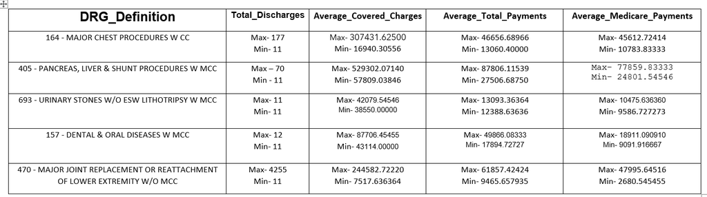